# three_materials

```python
import numpy as np
import pandas as pd
import matplotlib
import matplotlib.pyplot as plt

import sys
sys.path.append("../../scripts")
import importlib

import model
importlib.reload(model)
from model import Model, model_from_file

import model_plot
importlib.reload(model_plot)
from model_plot import model_plot

%matplotlib inline
```

## Непостоянный параметр $\Gamma$

Рассмотрим типичное решение со старыми параметрами, но $\Gamma$ зададим кусочно постоянной, как указано далее.

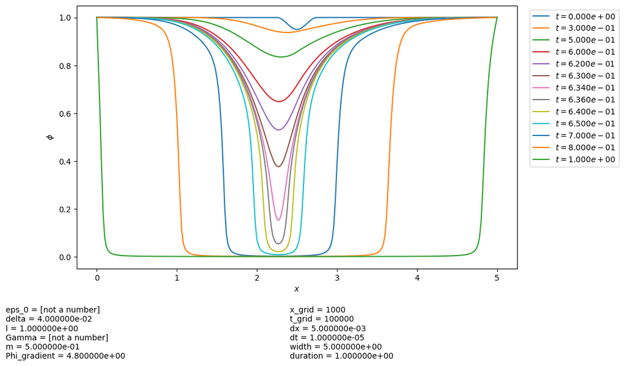

```python
model_skew = model_from_file('data/model_skew.csv')
model_plot(model_skew, [0, 0.3, 0.5, 0.6, 0.62, 0.63, 0.634, 0.636, 0.64, 0.65, 0.7, 0.8, 1], figsize=(10, 6))
# Gamma() =
#	[0, 2.5]: 1
#	[2.5, 5]: 1.5
```

## Эксперимент с высоким напряжением

Если задать модели параметры материала №1 из файла, то канал пробоя растет невыносимо долго. Увеличим напряжение и посмотрим, как ведет себя сеточное решение.

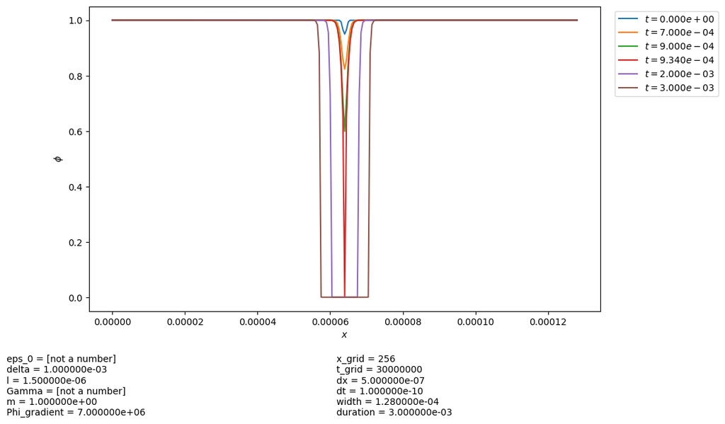

```python
model_one_high_E = model_from_file('data/model_one_high_E.csv')
model_plot(model_one_high_E, [0, 7e-4, 9e-4, 9.335e-4, 2e-3, 3e-3], figsize=(10, 6))
```

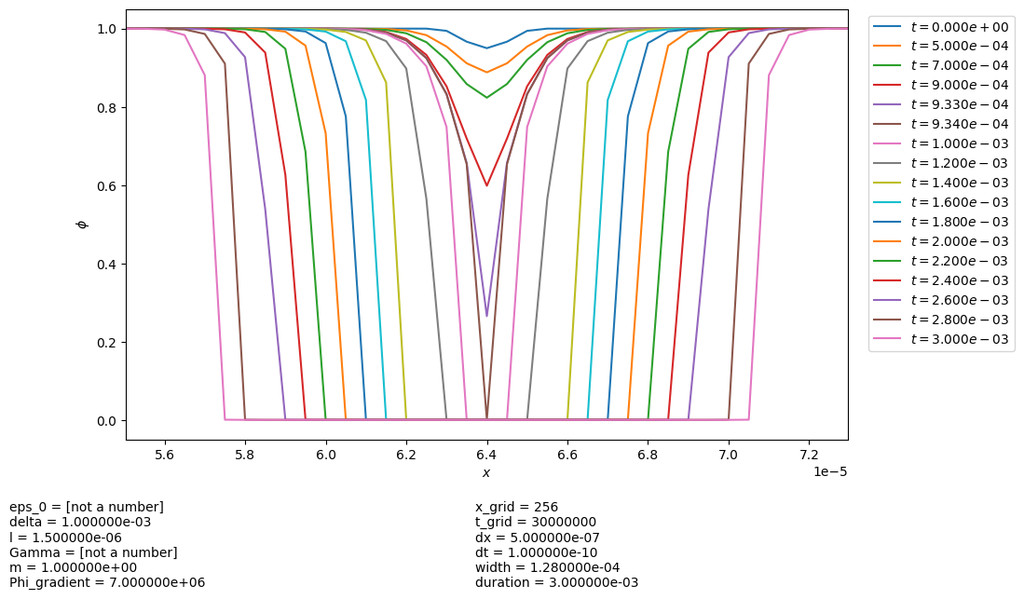

```python
model_plot(model_one_high_E, [
    0, 5e-4, 7e-4, 9e-4, 9.33e-4, 9.34e-4, 1e-3, 1.2e-3, 1.4e-3, 1.6e-3,
    1.8e-3, 2e-3, 2.2e-3, 2.4e-3, 2.6e-3, 2.8e-3, 3e-3
], figsize=(10, 6), xlim=[1.28e-4 * 0.43, 1.28e-4 * 0.57])
```

Построим графики составляющих свободной энергии.

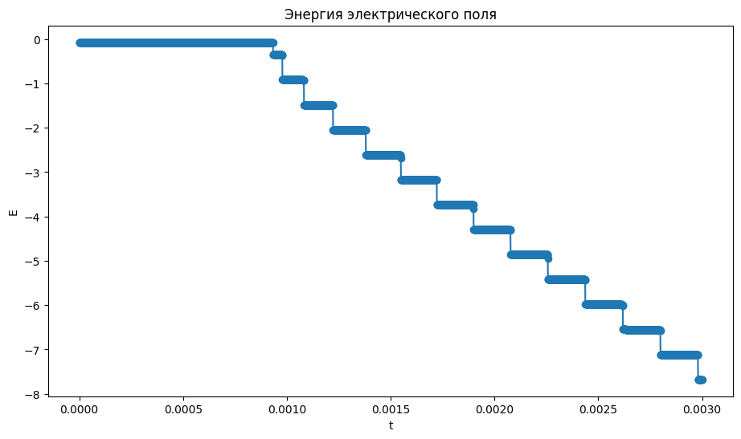

```python
plt.figure(figsize=(11, 6))
plt.title('Энергия электрического поля')
plt.xlabel('t')
plt.ylabel('E')
plt.plot(model_one_high_E.ts, model_one_high_E.energy_electrical, '-o')
plt.show()
```

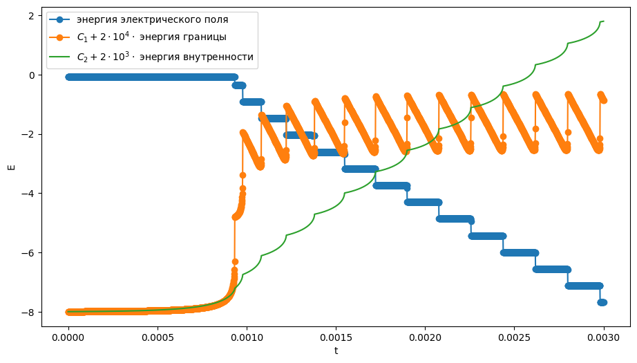

```python
plt.figure(figsize=(11, 6))
plt.xlabel('t')
plt.ylabel('E')
plt.plot(model_one_high_E.ts, model_one_high_E.energy_electrical, '-o')
plt.plot(model_one_high_E.ts, model_one_high_E.energy_border * 20000 - 8, '-o')
plt.plot(model_one_high_E.ts, model_one_high_E.energy_inner * 2000 - 8)
plt.legend([
    'энергия электрического поля',
    r'$C_1 + 2 \cdot 10^4 \cdot$ энергия границы',
    r'$C_2 + 2 \cdot 10^3 \cdot$ энергия внутренности'
])
plt.show()
```

Видны некие синхронные рывки, связынные, по-видимому, с поочередным "падением" узлов сетки от $\phi \approx 1$ к $\phi \approx 0$.

```python
model_one_high_E_energy = \
    model_one_high_E.energy_electrical + model_one_high_E.energy_border + model_one_high_E.energy_inner
model_one_high_E_Delta_energy = model_one_high_E_energy[1:] - model_one_high_E_energy[:-1]
print('Полная энергия падала, раз:\t', (model_one_high_E_Delta_energy < 0).sum())
print('Полная энергия возрастала, раз:\t', (model_one_high_E_Delta_energy > 0).sum())
```

```
Полная энергия падала, раз:	 3000
Полная энергия возрастала, раз:	 0
```

Из-за синхронизации рывков полная энергия все равно монотонно убывает.

## Сдвиг канала относительно узлов сетки

Сдвинем начальное возмущение так, чтобы оно не ложилось на узлы сетки регулярным образом.

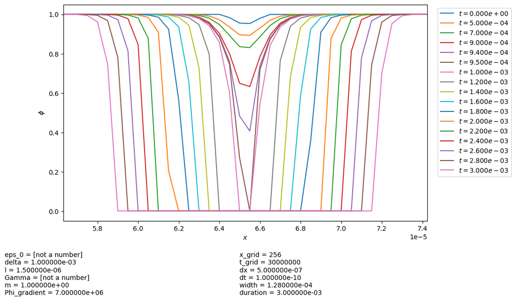

```python
model_one_high_E_moved = model_from_file('data/model_one_high_E_moved.csv')
model_plot(model_one_high_E_moved, [
    0, 5e-4, 7e-4, 9e-4, 9.4e-4, 9.5e-4, 1e-3, 1.2e-3, 1.4e-3, 1.6e-3,
    1.8e-3, 2e-3, 2.2e-3, 2.4e-3, 2.6e-3, 2.8e-3, 3e-3
], figsize=(10, 6), xlim=[1.28e-4 * 0.44, 1.28e-4 * 0.58])
```

Видно, что характер поведения системы не изменился, а время прорастания канала пробоя изменилось незначительно. Изменения можно списать на неточность даже не самого расчета, а задания начального возмущения.

## Два материала с различными $\epsilon_0$ и $\Gamma$

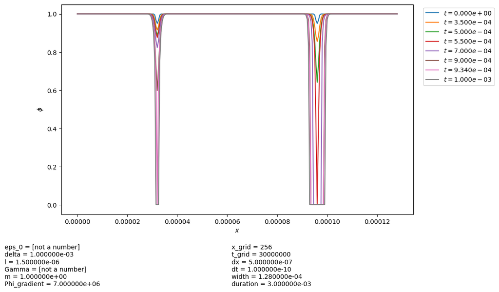

```python
model_two_high_E = model_from_file('data/model_two_high_E.csv')
model_plot(model_two_high_E, [0, 3.5e-4, 5e-4, 5.5e-4, 7e-4, 9e-4, 9.335e-4, 1e-3], figsize=(10, 6))
```

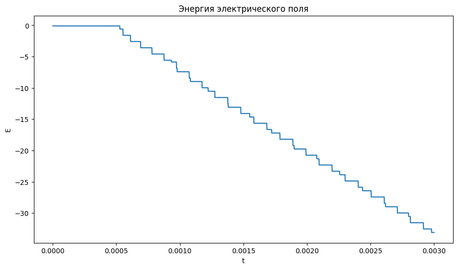

```python
plt.figure(figsize=(11, 6))
plt.title('Энергия электрического поля')
plt.xlabel('t')
plt.ylabel('E')
plt.plot(model_two_high_E.ts, model_two_high_E.energy_electrical)
plt.show()
```

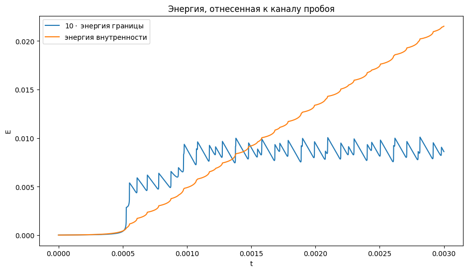

```python
plt.figure(figsize=(11, 6))
plt.title('Энергия, отнесенная к каналу пробоя')
plt.xlabel('t')
plt.ylabel('E')
plt.plot(model_two_high_E.ts, model_two_high_E.energy_border * 10)
plt.plot(model_two_high_E.ts, model_two_high_E.energy_inner)
plt.legend([
    r'$10 \cdot$ энергия границы',
    'энергия внутренности'
])
plt.show()
```

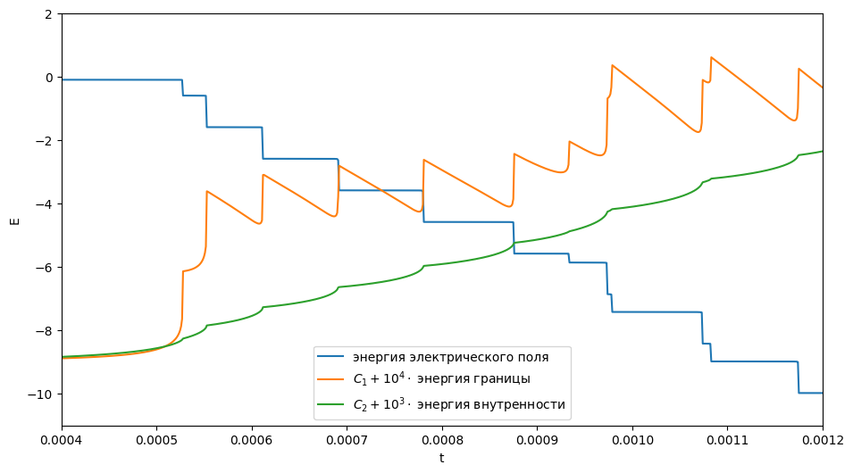

```python
plt.figure(figsize=(11, 6))
plt.xlabel('t')
plt.ylabel('E')
plt.xlim([4e-4, 1.2e-3])
plt.ylim([-11, 2])
plt.plot(model_two_high_E.ts, model_two_high_E.energy_electrical)
plt.plot(model_two_high_E.ts, model_two_high_E.energy_border * 10000 - 9)
plt.plot(model_two_high_E.ts, model_two_high_E.energy_inner * 1000 - 9)
plt.legend([
    'энергия электрического поля',
    r'$C_1 + 10^4 \cdot$ энергия границы',
    r'$C_2 + 10^3 \cdot$ энергия внутренности'
])
plt.show()
```

## Напряжение в соответствии с данными из файла

Понизим напряжение $K_\Phi \equiv E$ до значения, указанного в файле.

Время прорастания канала можно оценить по формуле $$T = \cfrac{-\ln A_0}{6 m \cdot (K_\Phi^2 \epsilon_0 - 2 \Gamma / l^2)}.$$

Возьмем материал №1 из файла. Материал №3 адекватно смоделировать невозможно; в материале №2 канал пробоя прорастает слишком быстро относительно материала №1 -- приблизим его свойства к материалу №1. Будут использоваться материалы со следующими параметрами.

| Материал | $\Gamma$ | $\epsilon_0$ |
| --- | --- | --- |
| №1 из файла | $2.6 \Gamma_0$ | $2.6 \epsilon_{00}$ |
| №2 новый | $2.7 \Gamma_0$ | $2.7 \epsilon_{00}$ |
| №3 новый | $2.8 \Gamma_0$ | $2.8 \epsilon_{00}$ |
| №4 новый | $3.0 \Gamma_0$ | $3.0 \epsilon_{00}$ |

Амплитуда начального возмущения $A_0 = 0.02$.

Проведем расчет с материалами №1, №3 и №4 из таблицы.

```python
model_three = model_from_file('data/model_three.csv')
```

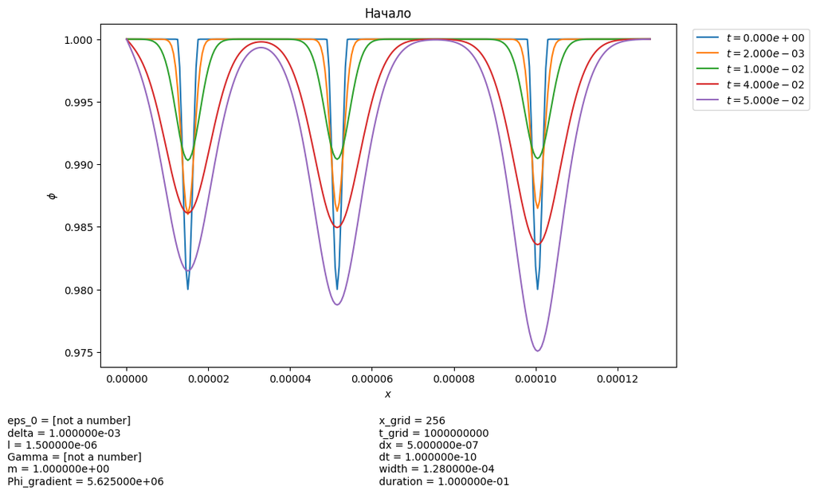

```python
model_plot(model_three, [0, 2e-3, 1e-2, 4e-2, 5e-2], figsize=(10, 6),
           title='Начало')
```

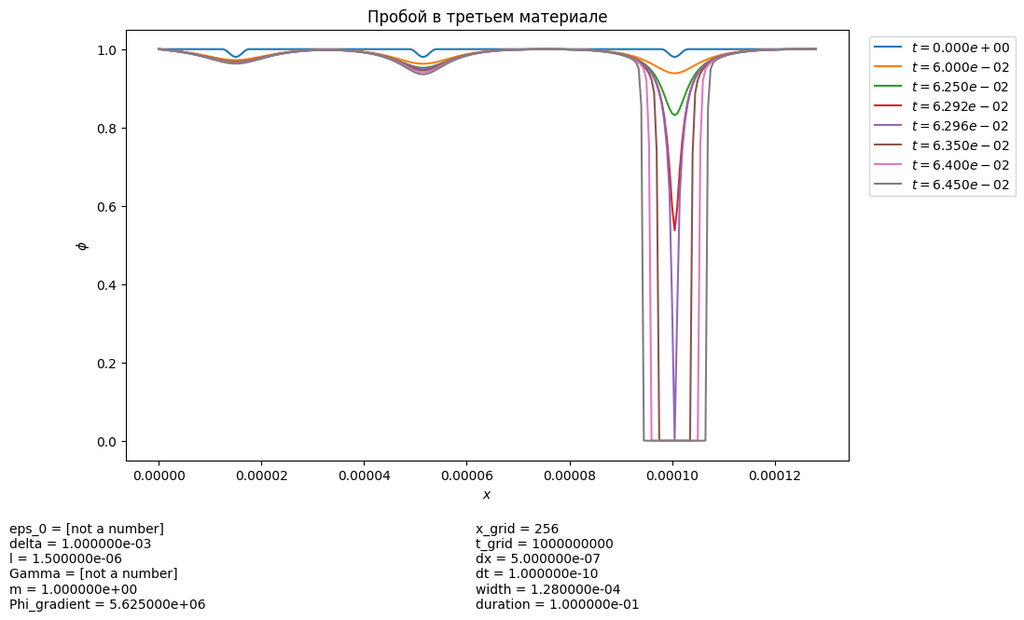

```python
model_plot(model_three, [0, 6e-2, 6.25e-2, 6.292e-2, 6.296e-2, 6.35e-2, 6.4e-2, 6.45e-2], figsize=(10, 6),
           title='Пробой в третьем материале')
```

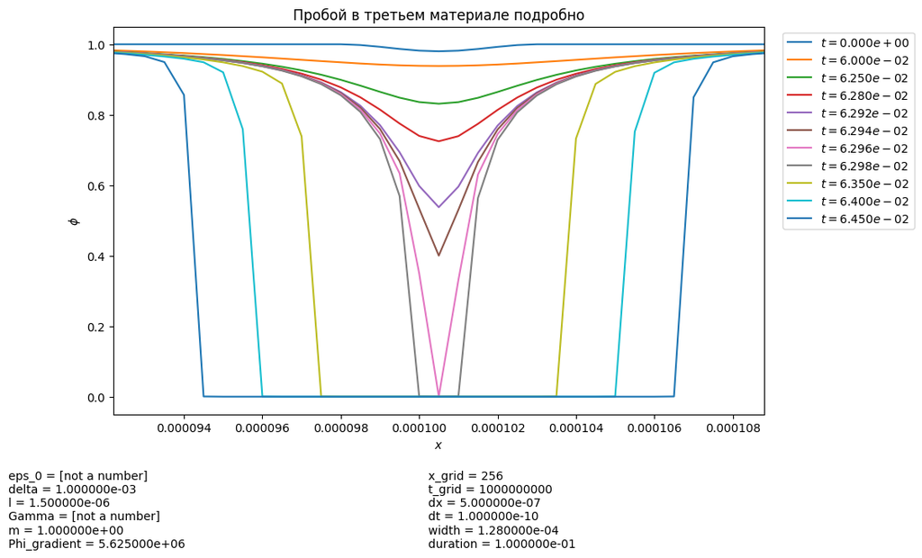

```python
model_plot(model_three, [
    0, 6e-2, 6.25e-2, 6.28e-2, 6.292e-2, 6.294e-2, 6.296e-2, 6.298e-2, 6.35e-2, 6.4e-2, 6.45e-2
], figsize=(10, 6), title='Пробой в третьем материале подробно', xlim=[1.28e-4 * 0.7203, 1.28e-4 * 0.85])
```

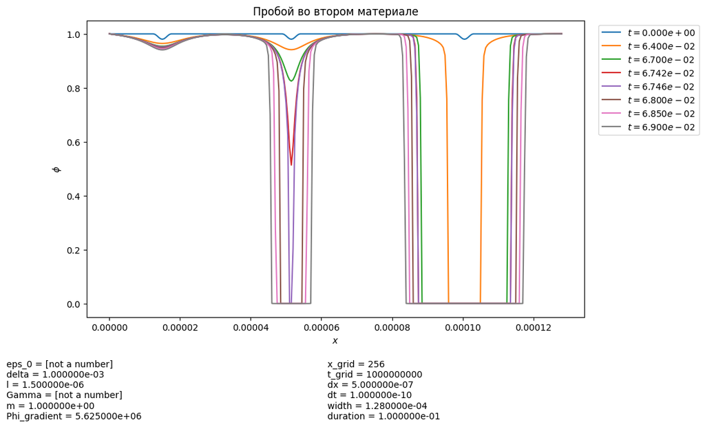

```python
model_plot(model_three, [0, 6.4e-2, 6.7e-2, 6.742e-2, 6.746e-2, 6.8e-2, 6.85e-2, 6.9e-2], figsize=(10, 6),
           title='Пробой во втором материале')
```

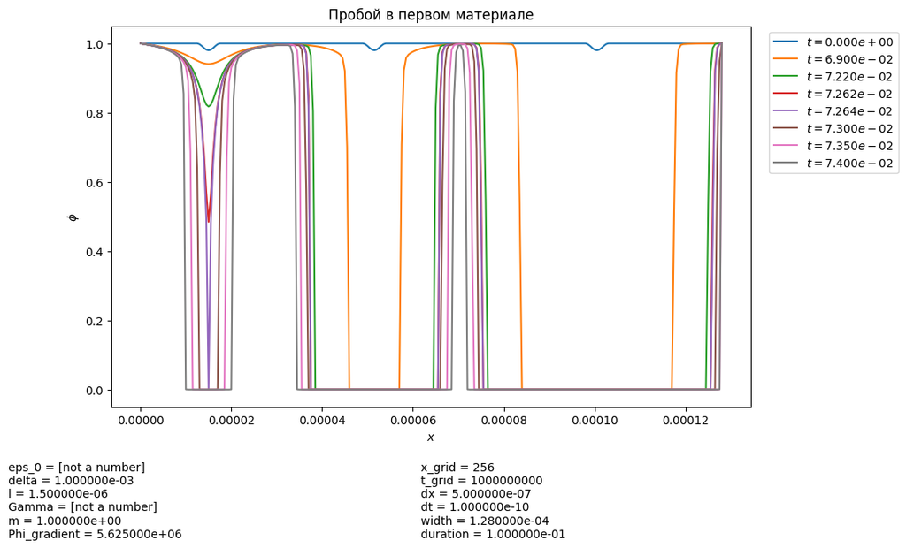

```python
model_plot(model_three, [0, 6.9e-2, 7.22e-2, 7.262e-2, 7.264e-2, 7.3e-2, 7.35e-2, 7.4e-2], figsize=(10, 6),
           title='Пробой в первом материале')
```

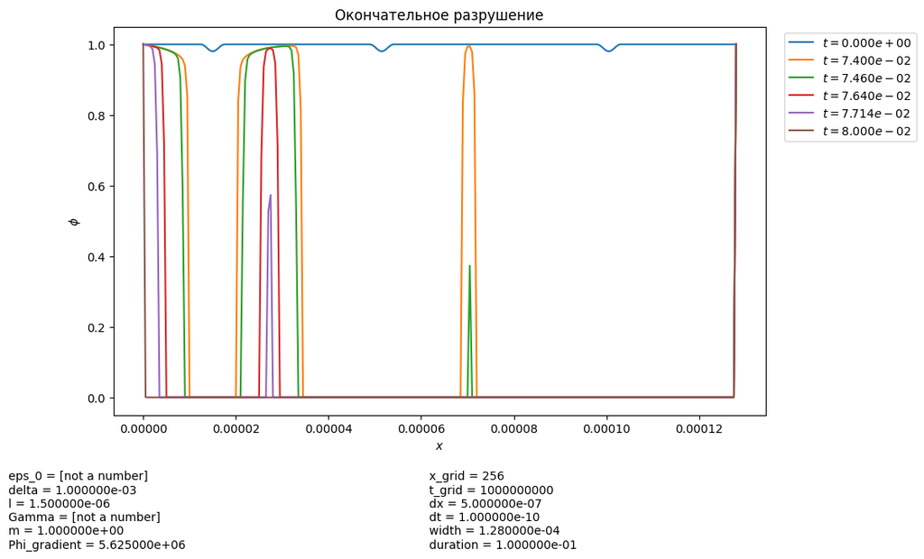

```python
model_plot(model_three, [0, 7.4e-2, 7.46e-2, 7.64e-2, 7.714e-2, 8e-2], figsize=(10, 6),
           title='Окончательное разрушение')
```

Построим графики составляющих свободной энергии.

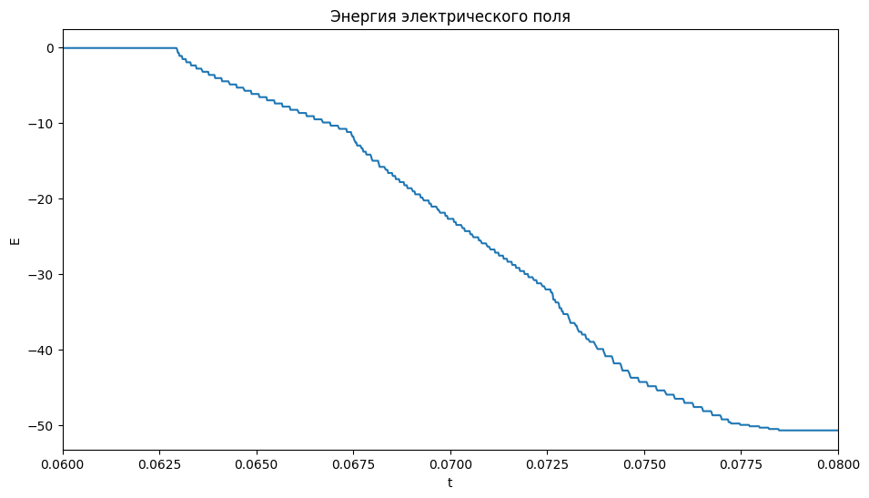

```python
plt.figure(figsize=(11, 6))
plt.title('Энергия электрического поля')
plt.xlabel('t')
plt.ylabel('E')
plt.xlim([0.06, 0.08])
plt.plot(model_three.ts, model_three.energy_electrical)
plt.show()
```

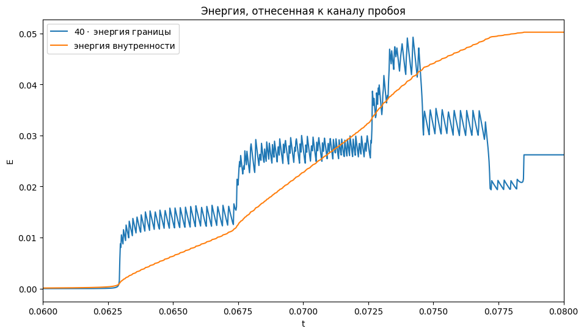

```python
plt.figure(figsize=(11, 6))
plt.title('Энергия, отнесенная к каналу пробоя')
plt.xlabel('t')
plt.ylabel('E')
plt.xlim([0.06, 0.08])
plt.plot(model_three.ts, model_three.energy_border * 40)
plt.plot(model_three.ts, model_three.energy_inner)
plt.legend([
    r'$40 \cdot$ энергия границы',
    'энергия внутренности'
])
plt.show()
```

```python
model_three_energy = \
    model_three.energy_electrical + model_three.energy_border + model_three.energy_inner
model_three_Delta_energy = model_three_energy[1:] - model_three_energy[:-1]
print('Полная энергия падала, раз:\t', (model_three_Delta_energy < 0).sum())
print('Полная энергия возрастала, раз:\t', (model_three_Delta_energy > 0).sum())
```

```
Полная энергия падала, раз:	 3703
Полная энергия возрастала, раз:	 227
```

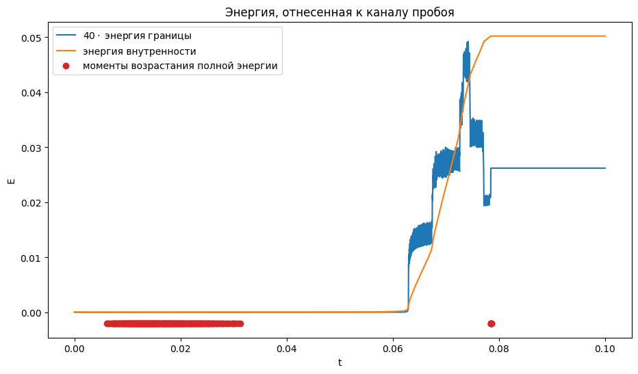

```python
plt.figure(figsize=(11, 6))
plt.title('Энергия, отнесенная к каналу пробоя')
plt.xlabel('t')
plt.ylabel('E')
plt.plot(model_three.ts, model_three.energy_border * 40)
plt.plot(model_three.ts, model_three.energy_inner)
ts_of_energy_increase = model_three.ts[:-1][model_three_Delta_energy > 0]
plt.scatter(ts_of_energy_increase, np.zeros_like(ts_of_energy_increase) - 0.002, color='C3')
plt.legend([
    r'$40 \cdot$ энергия границы',
    'энергия внутренности',
    'моменты возрастания полной энергии'
])
plt.show()
```

Проведем расчет с материалами №1, №2 и №3 из таблицы.

```python
model_three_slower = model_from_file('data/model_three_slower.csv')
```

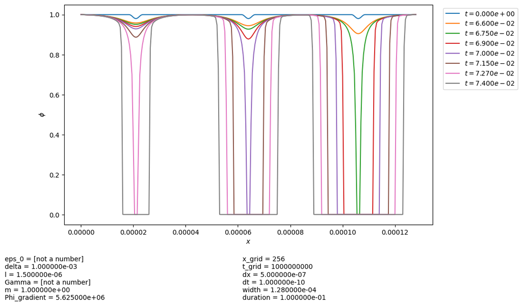

```python
model_plot(model_three_slower, [
    0, 6.6e-2, 6.75e-2, 6.9e-2, 7e-2, 7.15e-2, 7.27e-2, 7.4e-2
], figsize=(10, 6))
```

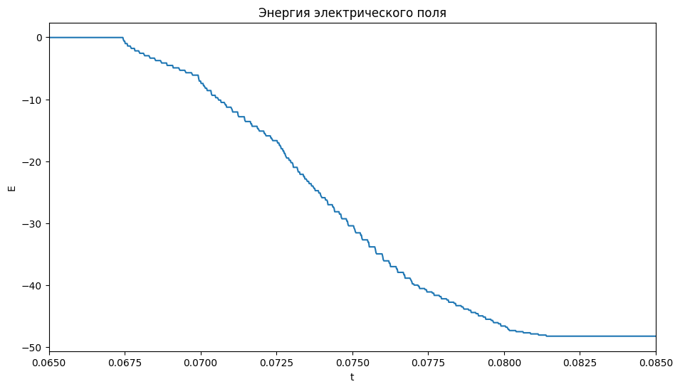

```python
plt.figure(figsize=(11, 6))
plt.title('Энергия электрического поля')
plt.xlabel('t')
plt.ylabel('E')
plt.xlim([0.065, 0.085])
plt.plot(model_three_slower.ts, model_three_slower.energy_electrical)
plt.show()
```

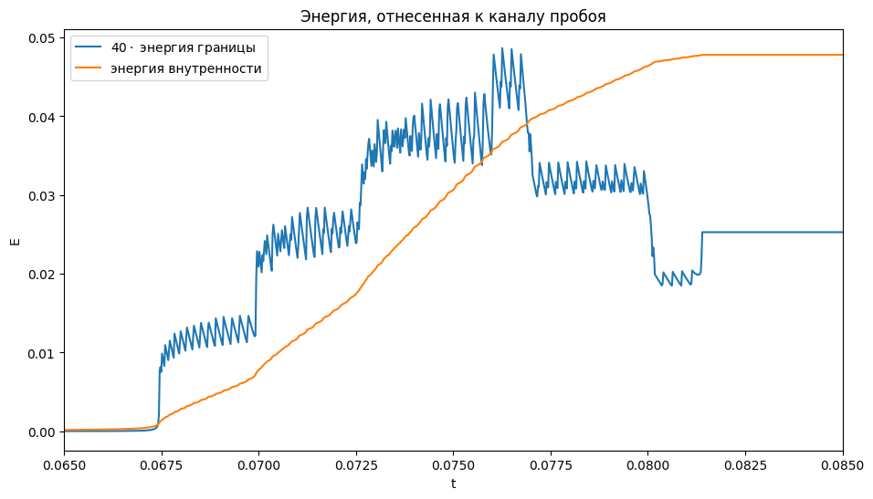

```python
plt.figure(figsize=(11, 6))
plt.title('Энергия, отнесенная к каналу пробоя')
plt.xlabel('t')
plt.ylabel('E')
plt.xlim([0.065, 0.085])
plt.plot(model_three_slower.ts, model_three_slower.energy_border * 40)
plt.plot(model_three_slower.ts, model_three_slower.energy_inner)
plt.legend([
    r'$40 \cdot$ энергия границы',
    'энергия внутренности'
])
plt.show()
```

```python
model_three_slower_energy = \
    model_three_slower.energy_electrical + model_three_slower.energy_border + model_three_slower.energy_inner
model_three_slower_Delta_energy = model_three_slower_energy[1:] - model_three_slower_energy[:-1]
print('Полная энергия падала, раз:\t', (model_three_slower_Delta_energy < 0).sum())
print('Полная энергия возрастала, раз:\t', (model_three_slower_Delta_energy > 0).sum())
```

```
Полная энергия падала, раз:	 3814
Полная энергия возрастала, раз:	 262
```

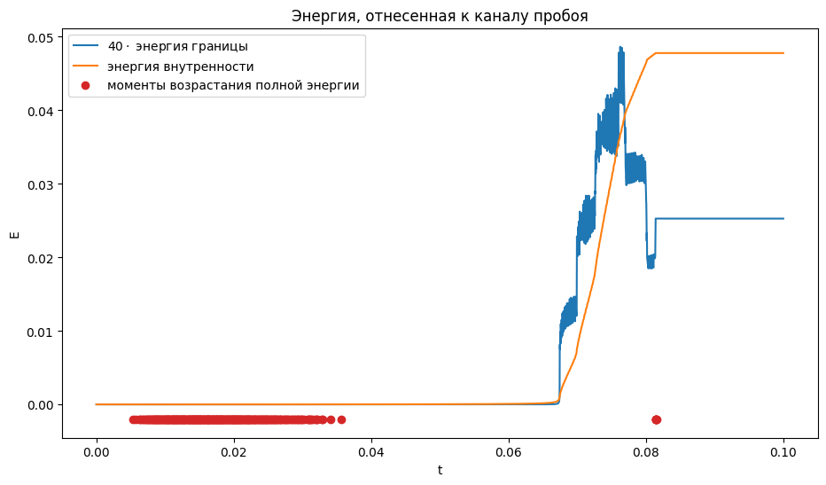

```python
plt.figure(figsize=(11, 6))
plt.title('Энергия, отнесенная к каналу пробоя')
plt.xlabel('t')
plt.ylabel('E')
plt.plot(model_three_slower.ts, model_three_slower.energy_border * 40)
plt.plot(model_three_slower.ts, model_three_slower.energy_inner)
ts_of_energy_increase = model_three_slower.ts[:-1][model_three_slower_Delta_energy > 0]
plt.scatter(ts_of_energy_increase, np.zeros_like(ts_of_energy_increase) - 0.002, color='C3')
plt.legend([
    r'$40 \cdot$ энергия границы',
    'энергия внутренности',
    'моменты возрастания полной энергии'
])
plt.show()
```